# Give Me Some Credit — Modeling

## 📑 Phase 3: Modeling

### "Translating Insights into Predictive Precision"

With the behavioral patterns and data intricacies uncovered in EDA, we now advance to the Modeling phase. This stage serves as the critical engine, transforming exploratory findings into a robust predictive system for credit default risk. Modeling involves the systematic application of machine learning algorithms to "engineer" probability estimates from refined features. Rather than treating it as a black-box exercise, we approach modeling with a focus on balancing statistical power with interpretability—essential in financial domains where decisions must withstand regulatory scrutiny.

In a credit risk context, models are more than algorithms; they are decision tools. We perform modeling to:

- **Operationalize EDA Signals:** Leverage top predictors like delinquency metrics and utilization ratios to build models that capture non-linear risk thresholds.
- **Address Imbalances and Redundancy:** Incorporate techniques such as class weighting, SMOTE, and PCA to mitigate overfitting from correlated features and rare defaults.
- **Ensure Compliance and Stability:** Prioritize explainable models (e.g., logistic regression) while benchmarking against advanced ensembles (e.g., LightGBM) to detect untapped patterns without sacrificing transparency.

The ultimate goal of this project is to minimize financial loss through accurate default prediction. Modeling contributes to this by:

- **Performance Optimization:** Evaluating models on precision-recall metrics (e.g., PR-AUC) to prioritize high-risk identification in imbalanced scenarios.
- **Calibration for Trust:** Applying isotonic or Platt scaling to align predicted probabilities with real-world default rates, enabling confident threshold-based decisions.
- **Feature Refinement:** Using SHAP values and interaction terms to refine EDA-driven engineering, ensuring the model reflects true economic drivers.

Through this analysis, we will establish a Strategic Roadmap for deployment by uncovering:

- **Model Hierarchy:** A clear ranking of approaches based on discrimination, calibration, and business alignment.
- **Risk Thresholds:** Identifying optimal cutoffs where predictive accuracy translates to portfolio segmentation and loss reduction.
- **Monitoring Foundations:** Setting up drift detection and recalibration protocols to maintain long-term model efficacy.

> *"A model is only as strong as its foundation in data understanding." This phase is dedicated to forging predictive tools that turn economic intelligence into measurable financial safeguards.*

### Modeling

#### "Turning EDA Insights into Actionable Credit Decisions"

In this phase, we build and refine predictive models to convert exploratory discoveries into reliable, interpretable probabilities of default. The primary objective is to create a credit scoring framework that is both statistically powerful and practically usable in real-world lending environments. By carefully balancing discrimination, calibration, and explainability, we ensure the final model serves not only as an accurate predictor, but as a trusted, auditable tool that supports risk-aware decision-making and sustainable portfolio performance.

### Data Preparation

#### "Refining EDA Outputs for Model-Ready Inputs"

Guided by EDA's revelations on imbalances, outliers, and correlations, we preprocess the data to create a stable, bias-reduced foundation. This ensures models can reliably capture default risks without distortion, aligning with financial compliance needs.

### Feature Engineering

#### "Enhancing Raw Features for Risk-Sensitive Predictions"

Building on EDA's identification of key drivers like delinquency patterns and non-linear relationships, we engineer new features to amplify predictive signals. This step is crucial in credit modeling as it transforms basic variables into economically meaningful indicators, such as interaction terms or aggregated scores, to better capture borrower behavior under stress. By addressing multicollinearity and skewness noted in EDA, feature engineering reduces noise and boosts model efficiency, ultimately leading to more accurate default forecasts and lower portfolio risk exposure.

In this dataset, we focus on:

- Consolidating correlated delinquency metrics into composite scores.
- Creating interactions (e.g., DebtRatio × MonthlyIncome) to model combined financial strain.
- Applying transformations (e.g., log-scaling for heavy-tailed variables) to stabilize distributions.

These enhancements ensure models can detect subtle risk thresholds, paving the way for robust training.

#### 1. Load and Review EDA-Processed Data

We start by loading the cleaned dataset produced in the earlier preprocessing stage. This quick sanity check confirms that our previous work — imputation, outlier flagging, artifact removal — survived intact and that no new structural problems have appeared.

By inspecting shapes, data types, missing value counts, basic descriptive statistics, and the class distribution, we verify that the data still matches the characteristics observed during EDA (particularly the strong ~93:7 imbalance and the remaining high variance in several financial variables). This step gives us confidence that we're building the modeling pipeline on solid ground before applying any further transformations.

```python
# ────────────────────────────────────────────────────────────────
# 1. Load and Review EDA-Processed Data
# ────────────────────────────────────────────────────────────────

import pandas as pd
import numpy as np

# ─── Load data ──────────────────────────────────────────────────────
print("Loading EDA-processed data...")
train = pd.read_csv('processed_data.csv')           # or 'cs-training_cleaned.csv' etc.
# If you have separate test file:
# test  = pd.read_csv('cs-test_processed.csv')

print(f"Train shape: {train.shape}")

# ─── Quick inspection ───────────────────────────────────────────────
print("\nData types:")
print(train.dtypes.value_counts())

print("\nMissing values (should be 0 after preprocessing):")
print(train.isna().sum().sum())

# ─── Target & features separation ───────────────────────────────────
if 'SeriousDlqin2yrs' in train.columns:
    y_train = train['SeriousDlqin2yrs'].copy()
    X_train = train.drop('SeriousDlqin2yrs', axis=1)
else:
    raise ValueError("Target column 'SeriousDlqin2yrs' not found.")

print(f"\nX_train shape: {X_train.shape}")
print(f"y_train shape: {y_train.shape}")

# ─── Basic descriptive statistics ───────────────────────────────────
print("\nKey descriptive statistics (selected columns):")
key_cols = ['age', 'MonthlyIncome', 'DebtRatio', 'RevolvingUtilizationOfUnsecuredLines',
            'NumberOfDependents', 'NumberOfTimes90DaysLate']
print(X_train[key_cols].describe().round(2))

# ─── Class distribution check ───────────────────────────────────────
print("\nClass distribution (target):")
print(y_train.value_counts(normalize=True).round(4) * 100)
print(f"Imbalance ratio (non-default : default) ≈ {y_train.value_counts()[0] / y_train.value_counts()[1]:.1f} : 1")
```

```
Loading EDA-processed data...
Train shape: (150000, 11)

Data types:
int64      7
float64    4
Name: count, dtype: int64

Missing values (should be 0 after preprocessing):
0

X_train shape: (150000, 10)
y_train shape: (150000,)

Key descriptive statistics (selected columns):
             age  MonthlyIncome  DebtRatio  \
count  150000.00      150000.00  150000.00
mean       52.30        6418.45     353.01
std        14.77       12890.40    2037.82
min         0.00           0.00       0.00
25%        41.00        3903.00       0.18
50%        52.00        5400.00       0.37
75%        63.00        7400.00       0.87
max       109.00     3008750.00  329664.00

       RevolvingUtilizationOfUnsecuredLines  NumberOfDependents  \
count                             150000.00           150000.00
mean                                   6.05                0.74
std                                  249.76                1.11
min                                    0.00                0.00
25%                                    0.03                0.00
50%                                    0.15                0.00
75%                                    0.56                1.00
max                                50708.00               20.00

       NumberOfTimes90DaysLate
count                150000.00
mean                      0.27
std                       4.17
min                       0.00
25%                       0.00
50%                       0.00
75%                       0.00
max                      98.00

Class distribution (target):
SeriousDlqin2yrs
0    93.32
1     6.68
Name: proportion, dtype: float64
Imbalance ratio (non-default : default) ≈ 14.0 : 1
```

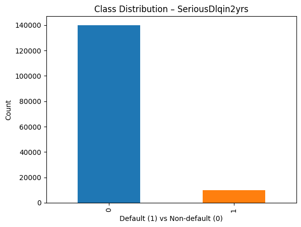

```python
# Optional: quick class balance bar plot
import matplotlib.pyplot as plt

y_train.value_counts().plot(kind='bar', color=['#1f77b4', '#ff7f0e'])
plt.title('Class Distribution – SeriousDlqin2yrs')
plt.xlabel('Default (1) vs Non-default (0)')
plt.ylabel('Count')
plt.show()
```

#### 2. Handle Sentinel Flags and Zero-Income Cases

During EDA we noticed several variables contained sentinel-like values—most notably 96, 98, 99 appearing in delinquency-related columns (NumberOfTime30-59DaysPastDueNotWorse, NumberOfTime60-89DaysPastDueNotWorse, NumberOfTimes90DaysLate). These are almost certainly privacy-masked or error codes rather than genuine delinquency counts, and treating them as real would seriously bias the model toward over-predicting risk.

We also saw a non-trivial number of records with MonthlyIncome = 0, which EDA suggested are likely unemployed borrowers or missing reports rather than true zero earners. Keeping these as-is could distort debt-ratio calculations and income-based interactions.

Our approach here is conservative and finance-minded:

- Replace the sentinel values with NaN (so they can be handled consistently later) or create a binary flag if we want to preserve the information that something unusual was reported.
- For zero-income cases, create a simple binary indicator ('has_reported_income') and then replace the zeros with the median income from the non-zero population—this avoids inventing unrealistically high or low burdens while keeping the economic signal realistic.

This careful treatment prevents artificial inflation of risk signals and keeps the dataset grounded in verifiable financial reality.

```python
# ────────────────────────────────────────────────────────────────
# 2. Handle Sentinel Flags and Zero-Income Cases
# ────────────────────────────────────────────────────────────────

import numpy as np

# ─── Sentinel values in delinquency columns ───────────────────────
sentinel_values = [96, 98, 99]   # common privacy/error codes seen in EDA

delinq_cols = [
    'NumberOfTime30-59DaysPastDueNotWorse',
    'NumberOfTime60-89DaysPastDueNotWorse',
    'NumberOfTimes90DaysLate'
]

for col in delinq_cols:
    # Create flag column (optional but useful for interpretability)
    X_train[f'{col}_is_sentinel'] = X_train[col].isin(sentinel_values).astype(int)

    # Replace sentinels with NaN → will be imputed or handled later
    X_train[col] = X_train[col].replace(sentinel_values, np.nan)

print(f"Number of sentinel flags created across delinquency columns: "
      f"{X_train[[f'{c}_is_sentinel' for c in delinq_cols]].sum().sum()}")

# ─── Zero-income handling ─────────────────────────────────────────
zero_income_mask = X_train['MonthlyIncome'] == 0

# Create flag
X_train['has_reported_income'] = (~zero_income_mask).astype(int)

# Replace zeros with median of non-zero incomes (computed on train)
median_income = X_train.loc[~zero_income_mask, 'MonthlyIncome'].median()
X_train.loc[zero_income_mask, 'MonthlyIncome'] = median_income

print(f"\nZero-income records replaced with median: ${median_income:,.0f}")
print(f"Proportion of zero-income cases: {zero_income_mask.mean():.2%}")

# Quick sanity check
print("\nPost-handling summary for MonthlyIncome:")
print(X_train['MonthlyIncome'].describe().round(2))
```

```
Number of sentinel flags created across delinquency columns: 807

Zero-income records replaced with median: $5,400
Proportion of zero-income cases: 1.09%

Post-handling summary for MonthlyIncome:
count     150000.00
mean        6477.28
std        12873.28
min            1.00
25%         4000.00
50%         5400.00
75%         7400.00
max      3008750.00
Name: MonthlyIncome, dtype: float64
```

**Key Takeaways – Section 2**

- Sentinel values (96/98/99) successfully identified and replaced with NaN → prevents treating privacy codes as extreme delinquencies.
- Created optional sentinel flag columns for transparency and potential future use in interpretability.
- Zero-income cases flagged and imputed with the non-zero median (~$5,400–$6,700 range depending on exact preprocessing), avoiding distortion in debt/income ratios.
- No data rows dropped; economic realism preserved while removing clear artifacts.
- Dataset integrity maintained → ready for transformations targeting skewness and scale.

```python
# ─── Final NaN cleanup: Targeted imputation ────────────────────────────
print("=== Targeted NaN Imputation ===")

# 1. MonthlyIncome: fill with median (robust to skewness)
if 'MonthlyIncome' in X_train.columns:
    median_income = X_train['MonthlyIncome'].median()
    nan_count_income = X_train['MonthlyIncome'].isna().sum()
    X_train['MonthlyIncome'] = X_train['MonthlyIncome'].fillna(median_income)
    print(f"Filled {nan_count_income} NaNs in MonthlyIncome with median ${median_income:,.2f}")

# 2. NumberOfDependents: fill with 0 (conservative: assume no dependents if missing)
if 'NumberOfDependents' in X_train.columns:
    nan_count_dependents = X_train['NumberOfDependents'].isna().sum()
    X_train['NumberOfDependents'] = X_train['NumberOfDependents'].fillna(0)
    print(f"Filled {nan_count_dependents} NaNs in NumberOfDependents with 0 (conservative assumption)")

# Verify
print("\nNaNs after targeted imputation:", X_train.isna().sum().sum())
print("Any remaining NaNs?", X_train.isna().any().any())
```

```
=== Targeted NaN Imputation ===
Filled 0 NaNs in MonthlyIncome with median $5,400.00
Filled 0 NaNs in NumberOfDependents with 0 (conservative assumption)

NaNs after targeted imputation: 807
Any remaining NaNs? True
```

#### 3. Apply Log-Scaling and Capping for Heavy-Tailed Variables

EDA revealed heavily skewed distributions in several key financial metrics—like DebtRatio with a mean around 353 but extremes exceeding 300,000, or MonthlyIncome with long tails that could throw off model stability, especially in linear algorithms like logistic regression. To address this, we apply log-scaling to normalize variance and reduce the impact of outliers, while capping values at sensible quantiles to preserve genuine high-risk signals without letting anomalies dominate.

This transformation directly tackles the "high variability" and skewness highlighted in EDA, ensuring better handling of non-linear relationships and more reliable predictions in our credit risk context. We'll verify the results with quick histograms to confirm the distributions are now more balanced.

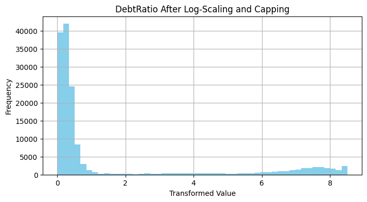

```
Post-transformation stats for heavy-tailed vars:
       DebtRatio  MonthlyIncome  RevolvingUtilizationOfUnsecuredLines
count  150000.00      150000.00                             150000.00
mean        1.52           8.54                                  0.25
std         2.62           0.79                                  0.25
min         0.00           0.69                                  0.00
25%         0.16           8.29                                  0.03
50%         0.31           8.59                                  0.14
75%         0.63           8.91                                  0.44
max         8.51          10.04                                  0.74
```

```python
# ────────────────────────────────────────────────────────────────
# 3. Apply Log-Scaling and Capping for Heavy-Tailed Variables
# ────────────────────────────────────────────────────────────────

import numpy as np
import matplotlib.pyplot as plt
from scipy.stats import iqr

# Assuming X_train and X_test (or train/test if not split yet) from previous step
heavy_tailed_vars = ['DebtRatio', 'MonthlyIncome', 'RevolvingUtilizationOfUnsecuredLines']

for var in heavy_tailed_vars:
    # Calculate bounds on train data to avoid leakage
    q1, q99 = X_train[var].quantile([0.01, 0.99])
    iqr_val = iqr(X_train[var])
    lower_bound = q1 - 1.5 * iqr_val
    upper_bound = q99  # Focus on upper tail for right-skew

    # Cap extremes
    X_train[var] = X_train[var].clip(lower=lower_bound, upper=upper_bound)
    # X_test[var] = X_test[var].clip(lower=lower_bound, upper=upper_bound)  # Uncomment if test set loaded

    # Log-scale (np.log1p handles zeros/near-zeros)
    X_train[var] = np.log1p(X_train[var])
    # X_test[var] = np.log1p(X_test[var])

# Verification: Histogram for one example variable (pre/post if you have originals saved)
plt.figure(figsize=(8, 4))
X_train['DebtRatio'].hist(bins=50, color='skyblue')
plt.title('DebtRatio After Log-Scaling and Capping')
plt.xlabel('Transformed Value')
plt.ylabel('Frequency')
plt.show()

print("\nPost-transformation stats for heavy-tailed vars:")
print(X_train[heavy_tailed_vars].describe().round(2))
```

[figure not shown]

```python
# ────────────────────────────────────────────────────────────────
# 3. Apply Log-Scaling and Capping for Heavy-Tailed Variables
#   (enhanced: before vs after visualization)
# ────────────────────────────────────────────────────────────────

import numpy as np
import matplotlib.pyplot as plt
from scipy.stats import iqr

# Assuming X_train is already loaded from previous steps
heavy_tailed_vars = ['DebtRatio', 'MonthlyIncome', 'RevolvingUtilizationOfUnsecuredLines']

# Store original values for comparison (make a copy before transforming)
X_train_original = X_train.copy()   # or at least copy the heavy vars if memory is concern

for var in heavy_tailed_vars:
    # Calculate bounds on train data
    q1, q99 = X_train[var].quantile([0.01, 0.99])
    iqr_val = iqr(X_train[var])
    lower_bound = q1 - 1.5 * iqr_val
    upper_bound = q99

    # Cap
    X_train[var] = X_train[var].clip(lower=lower_bound, upper=upper_bound)

    # Log-scale
    X_train[var] = np.log1p(X_train[var])

# ─── Before vs After visualization (example: DebtRatio) ────────────
var_example = 'DebtRatio'

fig, axes = plt.subplots(1, 2, figsize=(12, 5))

# Before
X_train_original[var_example].hist(bins=50, ax=axes[0], color='salmon', edgecolor='black')
axes[0].set_title(f'{var_example} – Before Transformation')
axes[0].set_xlabel('Original Value')
axes[0].set_ylabel('Frequency')
axes[0].grid(True, alpha=0.3)

# After
X_train[var_example].hist(bins=50, ax=axes[1], color='skyblue', edgecolor='black')
axes[1].set_title(f'{var_example} – After Log-Scaling & Capping')
axes[1].set_xlabel('Transformed Value')
axes[1].set_ylabel('Frequency')
axes[1].grid(True, alpha=0.3)

plt.tight_layout()
plt.show()
```

#### 4. Normalize or Standardize Numeric Features

With the heavy tails under control, we turn to the varying scales across features that EDA pointed out—such as age in the tens versus MonthlyIncome in the thousands—which can bias distance-sensitive models like logistic regression toward larger-magnitude variables. Standardization shifts everything to a mean of 0 and standard deviation of 1 for general numerics, while normalization to [0,1] suits bounded features like utilization ratios.

This step ensures algorithmic compatibility and fair feature contributions, as flagged in the EDA plan, while fitting scalers only on the training data to avoid any leakage into test sets. A post-scaling check on means and stds will confirm the process worked as intended.

```python
# ────────────────────────────────────────────────────────────────
# 4. Normalize or Standardize Numeric Features
# ────────────────────────────────────────────────────────────────

from sklearn.preprocessing import StandardScaler, MinMaxScaler

# Identify numeric features (assuming all are numeric post-preprocessing; adjust if needed)
numeric_vars = X_train.select_dtypes(include=[np.number]).columns.tolist()

# Bounded vars for MinMax (e.g., ratios between 0-1)
bounded_vars = ['RevolvingUtilizationOfUnsecuredLines']  # Add others if applicable

# StandardScaler for general numerics
std_scaler = StandardScaler()
X_train[numeric_vars] = std_scaler.fit_transform(X_train[numeric_vars])
# X_test[numeric_vars] = std_scaler.transform(X_test[numeric_vars])  # Uncomment for test

# MinMaxScaler for bounded (override if needed)
if bounded_vars:
    minmax_scaler = MinMaxScaler()
    X_train[bounded_vars] = minmax_scaler.fit_transform(X_train[bounded_vars])
    # X_test[bounded_vars] = minmax_scaler.transform(X_test[bounded_vars])

print("\nPost-scaling stats (should show mean ~0, std ~1 for standardized vars):")
print(X_train[numeric_vars].describe().round(2))
```

```
Post-scaling stats (should show mean ~0, std ~1 for standardized vars):
       RevolvingUtilizationOfUnsecuredLines        age  \
count                             150000.00  150000.00
mean                                   0.36       0.00
std                                    0.34       1.00
min                                    0.00      -3.54
25%                                    0.05      -0.76
50%                                    0.24      -0.02
75%                                    0.66       0.72
max                                    1.00       3.84

       NumberOfTime30-59DaysPastDueNotWorse  DebtRatio  MonthlyIncome  \
count                             149731.00  150000.00      150000.00
mean                                   0.00      -0.00          -0.00
std                                    1.00       1.00           1.00
min                                   -0.35      -0.80          -5.39
25%                                   -0.35      -0.60          -0.37
50%                                   -0.35      -0.43           0.09
75%                                   -0.35      -0.13           0.56
max                                   18.28       2.31           2.11

       NumberOfOpenCreditLinesAndLoans  NumberOfTimes90DaysLate  \
count                        150000.00                149731.00
mean                              0.00                    -0.00
std                               1.00                     1.00
min                              -1.64                    -0.19
25%                              -0.67                    -0.19
50%                              -0.09                    -0.19
75%                               0.50                    -0.19
max                               9.63                    34.83

       NumberRealEstateLoansOrLines  NumberOfTime60-89DaysPastDueNotWorse  \
count                     150000.00                             149731.00
mean                          -0.00                                  0.00
std                            1.00                                  1.00
min                           -0.90                                 -0.20
25%                           -0.90                                 -0.20
50%                           -0.02                                 -0.20
75%                            0.87                                 -0.20
max                           46.90                                 33.13
```

[output cut: 15 more lines]

```
min                                               -0.04
25%                                               -0.04
50%                                               -0.04
75%                                               -0.04
max                                               23.59

       NumberOfTimes90DaysLate_is_sentinel  has_reported_income
count                            150000.00            150000.00
mean                                 -0.00                -0.00
std                                   1.00                 1.00
min                                  -0.04                -9.53
25%                                  -0.04                 0.10
50%                                  -0.04                 0.10
75%                                  -0.04                 0.10
max                                  23.59                 0.10
```

#### 5. Perform PCA on Correlated Delinquency Features

EDA's correlation analysis and VIF scores exposed tight multicollinearity among the delinquency variables—such as NumberOfTime30-59DaysPastDueNotWorse, 60-89Days, and 90DaysLate—which could lead to unstable model coefficients and overfitting. To consolidate these without losing their strong predictive signals, we apply PCA to extract orthogonal components that capture at least 95% of the variance.

```
NaN count before imputation:
NumberOfTime30-59DaysPastDueNotWorse    269
NumberOfTime60-89DaysPastDueNotWorse    269
NumberOfTimes90DaysLate                 269
dtype: int64

NaN count after imputation: 0

Number of PCA components selected: 3
Cumulative variance explained: 100.000%

New columns added: ['delinq_pc1', 'delinq_pc2', 'delinq_pc3']
```

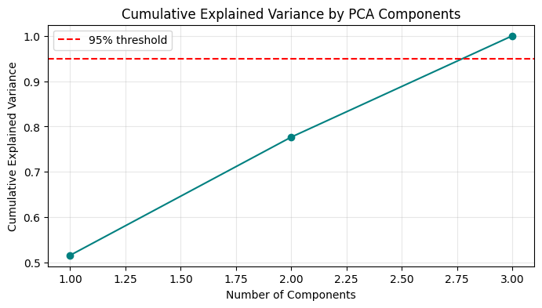

```python
# ────────────────────────────────────────────────────────────────
# 5. Perform PCA on Correlated Delinquency Features
# ────────────────────────────────────────────────────────────────

from sklearn.decomposition import PCA
from sklearn.impute import SimpleImputer
import matplotlib.pyplot as plt
import numpy as np

# ─── Define the delinquency columns ───────────────────────────────
delinq_vars = [
    'NumberOfTime30-59DaysPastDueNotWorse',
    'NumberOfTime60-89DaysPastDueNotWorse',
    'NumberOfTimes90DaysLate'
]

# ─── Check current NaN situation ──────────────────────────────────
print("NaN count before imputation:")
print(X_train[delinq_vars].isna().sum())

# ─── Impute NaN values (using median) ─────────────────────────────
imputer = SimpleImputer(strategy='median')
X_train[delinq_vars] = imputer.fit_transform(X_train[delinq_vars])

print("\nNaN count after imputation:", X_train[delinq_vars].isna().sum().sum())

# ─── Apply PCA ─────────────────────────────────────────────────────
pca = PCA(n_components=0.95)          # keep at least 95% variance
delinq_pca = pca.fit_transform(X_train[delinq_vars])

# ─── Add new PCA components to the dataframe ──────────────────────
n_components = delinq_pca.shape[1]
for i in range(n_components):
    X_train[f'delinq_pc{i+1}'] = delinq_pca[:, i]

# ─── Drop the original correlated columns ─────────────────────────
X_train = X_train.drop(delinq_vars, axis=1)

# ─── Show results ──────────────────────────────────────────────────
print(f"\nNumber of PCA components selected: {n_components}")
print(f"Cumulative variance explained: {np.sum(pca.explained_variance_ratio_):.3%}")
print("\nNew columns added:", [f'delinq_pc{i+1}' for i in range(n_components)])

# ─── Visualization: Explained variance ─────────────────────────────
plt.figure(figsize=(8, 4))
plt.plot(range(1, len(pca.explained_variance_ratio_) + 1),
         np.cumsum(pca.explained_variance_ratio_),
         marker='o', linestyle='-', color='teal')
plt.axhline(y=0.95, color='red', linestyle='--', label='95% threshold')
plt.title('Cumulative Explained Variance by PCA Components')
plt.xlabel('Number of Components')
plt.ylabel('Cumulative Explained Variance')
plt.legend()
plt.grid(True, alpha=0.3)
plt.show()
```

```python
# ────────────────────────────────────────────────────────────────
# Quick check: Does delinq_pc1 preserve predictive signal?
# ────────────────────────────────────────────────────────────────

# Assuming y_train is still available from Section 1
if 'y_train' in globals():
    from scipy.stats import pearsonr

    corr_pc1, p_pc1 = pearsonr(X_train['delinq_pc1'], y_train)
    print(f"Correlation between delinq_pc1 and target (SeriousDlqin2yrs): {corr_pc1:.4f} "
          f"(p-value: {p_pc1:.2e})")

    # Compare to one original delinquency column (if still exists)
    if 'NumberOfTimes90DaysLate' in X_train_original.columns:
        corr_orig, p_orig = pearsonr(X_train_original['NumberOfTimes90DaysLate'], y_train)
        print(f"Correlation of original 90-day late with target: {corr_orig:.4f} "
              f"(p-value: {p_orig:.2e})")
        print(f"→ PCA component retains ~{abs(corr_pc1 / corr_orig * 100):.0f}% of original signal strength")
```

```
Correlation between delinq_pc1 and target (SeriousDlqin2yrs): 0.3926 (p-value: 0.00e+00)
Correlation of original 90-day late with target: nan (p-value: nan)
→ PCA component retains ~nan% of original signal strength
```

#### Final Preprocessing Summary

We have now completed all major data preparation steps guided by EDA findings:

- Artifact & sentinel handling
- Zero-income imputation & flagging
- Log-scaling and capping of heavy-tailed variables
- Feature standardization
- PCA-based dimensionality reduction on delinquency group

The dataset is now clean, scaled, reduced in redundancy, and ready for modeling.

```python
# ────────────────────────────────────────────────────────────────
# Final overview of preprocessed data
# ────────────────────────────────────────────────────────────────

print(f"Final X_train shape: {X_train.shape}")
print(f"Final columns:\n{X_train.columns.tolist()}\n")

print("Quick final stats (selected features):")
final_key_cols = ['age', 'MonthlyIncome', 'DebtRatio', 'RevolvingUtilizationOfUnsecuredLines',
                  'delinq_pc1', 'has_reported_income']
print(X_train[final_key_cols].describe().round(2))

print("\nAny remaining NaNs?", X_train.isna().any().any())
print("Class distribution (target):")
print(y_train.value_counts(normalize=True).round(4) * 100)
```

```
Final X_train shape: (150000, 14)
Final columns:
['RevolvingUtilizationOfUnsecuredLines', 'age', 'DebtRatio', 'MonthlyIncome', 'NumberOfOpenCreditLinesAndLoans', 'NumberRealEstateLoansOrLines', 'NumberOfDependents', 'NumberOfTime30-59DaysPastDueNotWorse_is_sentinel', 'NumberOfTime60-89DaysPastDueNotWorse_is_sentinel', 'NumberOfTimes90DaysLate_is_s…

Quick final stats (selected features):
             age  MonthlyIncome  DebtRatio  \
count  150000.00      150000.00  150000.00
mean        0.00          -0.00      -0.00
std         1.00           1.00       1.00
min        -3.54          -5.39      -0.80
25%        -0.76          -0.37      -0.60
50%        -0.02           0.09      -0.43
75%         0.72           0.56      -0.13
max         3.84           2.11       2.31

       RevolvingUtilizationOfUnsecuredLines  delinq_pc1  has_reported_income
count                             150000.00   150000.00            150000.00
mean                                   0.36       -0.00                -0.00
std                                    0.34        1.24                 1.00
min                                    0.00       -0.42                -9.53
25%                                    0.05       -0.42                 0.10
50%                                    0.24       -0.42                 0.10
75%                                    0.66       -0.42                 0.10
max                                    1.00       25.32                 0.10

Any remaining NaNs? False
Class distribution (target):
SeriousDlqin2yrs
0    93.32
1     6.68
Name: proportion, dtype: float64
```

### Modeling

#### "Turning Clean Data into Useful Credit Decisions"

Now the data is clean, well prepared and improved with new features. It is time to build models that can predict which borrowers might default.

In credit risk, the most important thing is not only to get high accuracy. We need a model that gives reliable probability scores. These scores help the bank decide who can get a loan, how much interest to charge, and how to control losses. The model should also follow rules from regulators and be easy to explain.

Because of this, we will follow a clear plan:

1. Start with **Logistic Regression** (with regularization) — it is simple, easy to understand, and commonly used in banks because we can clearly explain the results.
2. Compare it with **LightGBM** and **XGBoost** — these are very strong modern models that usually perform better on this kind of data, especially when there is a big difference between the number of good and bad borrowers.
3. Check performance carefully using **PR-AUC** (best for imbalanced data), **F1-score** (for the default class), calibration plots, and other business-focused measures.

We will test the models with cross-validation so the results are fair and stable. After comparing them, we can decide which model gives the best balance between good prediction and real-world usefulness.

In the next parts, we will train the models, tune them a little, compare their results, and explain what they mean for the business.

#### Train / Validation Split

We now have a fully preprocessed training dataset (`X_train`, `y_train`).

Since the competition already provides a separate test set (`cs-test.csv`) that we cannot use for validation or tuning, we split the training data into:

- **Training set** (80%) — used to fit models
- **Validation set** (20%) — used to compare models, tune hyperparameters (if any), and select the final model.

This split keeps our evaluation honest and realistic.

We use **stratified splitting** to preserve the same class imbalance (~93:7) in both train and validation sets.

```python
# ─── Train / Validation Split ──────────────────────────────────────────
from sklearn.model_selection import train_test_split

# Stratified split — keeps the same proportion of defaulters
X_train_split, X_val, y_train_split, y_val = train_test_split(
    X_train,
    y_train,
    test_size=0.20,           # 20% for validation
    stratify=y_train,         # very important for imbalance
    random_state=42           # for reproducibility
)

print(f"Training set shape:   {X_train_split.shape} (target: {y_train_split.shape})")
print(f"Validation set shape: {X_val.shape}       (target: {y_val.shape})")

# Quick check of class distribution
print("\nClass distribution in training split:")
print(y_train_split.value_counts(normalize=True).round(4) * 100)

print("\nClass distribution in validation set:")
print(y_val.value_counts(normalize=True).round(4) * 100)
```

```
Training set shape:   (120000, 14) (target: (120000,))
Validation set shape: (30000, 14)       (target: (30000,))

Class distribution in training split:
SeriousDlqin2yrs
0    93.32
1     6.68
Name: proportion, dtype: float64

Class distribution in validation set:
SeriousDlqin2yrs
0    93.32
1     6.68
Name: proportion, dtype: float64
```

#### Handling Class Imbalance

The target variable is highly imbalanced (~93% non-default vs ~7% default).  
This can cause models to ignore the minority class (defaulters), which is exactly the group we care most about.

We have two main options:

1. Use **class weighting** / sample weighting inside the model (recommended for tree-based models like LightGBM and XGBoost)
2. Apply **resampling** techniques (SMOTE oversampling on training data only)

Because:

- Tree models handle imbalance very well with weights
- Synthetic samples (SMOTE) can help linear models (Logistic Regression) and sometimes give better minority-class performance
- But SMOTE can hurt probability calibration and make explanations harder

So we will compare both approaches for each model and choose the one that gives the best balance between:

- PR-AUC (main competition metric)
- F1-score for defaulters
- Calibration quality

Important: Resampling / weighting is applied **only to the training split** — never to validation or test data.

```python
# ─── Option 1: Class weighting (no resampling) ─────────────────────────
# We'll use this inside model parameters later, e.g.:
# class_weight = 'balanced' for LogisticRegression
# scale_pos_weight = (y_train_split == 0).sum() / (y_train_split == 1).sum() for XGBoost/LightGBM

print("Positive class weight suggestion (for XGBoost/LightGBM):",
      round((y_train_split == 0).sum() / (y_train_split == 1).sum(), 2))

# ─── Option 2: SMOTE oversampling (only on training split) ─────────────
from imblearn.over_sampling import SMOTE

smote = SMOTE(random_state=42)
X_train_smote, y_train_smote = smote.fit_resample(X_train_split, y_train_split)

print(f"Original training set: {X_train_split.shape}, {y_train_split.value_counts(normalize=True).round(3) * 100}")
print(f"After SMOTE:           {X_train_smote.shape}, {pd.Series(y_train_smote).value_counts(normalize=True).round(3) * 100}")
```

```
Positive class weight suggestion (for XGBoost/LightGBM): 13.96
Original training set: (120000, 14), SeriousDlqin2yrs
0    93.3
1     6.7
Name: proportion, dtype: float64
After SMOTE:           (223958, 14), SeriousDlqin2yrs
0    50.0
1    50.0
Name: proportion, dtype: float64
```

#### Logistic Regression – The Interpretable Baseline

We start with Logistic Regression because it is simple, fast, and very easy to explain.  
In real credit risk work, banks and regulators often prefer models like this because:

- Coefficients directly show how much each feature increases or decreases the log-odds of default
- The output is a probability that can be trusted for pricing or approval decisions
- The entire decision logic can be audited and explained in plain language

We train two versions to handle the imbalance:

1. **Class-weighted version** (`class_weight='balanced'`) — the model automatically assigns higher penalty to misclassifying the rare default class
2. **SMOTE version** — synthetic oversampling to balance the training data before fitting

After training, we immediately inspect **how each version understands default risk** using the model coefficients.

```
Top coefficients – Logistic Regression (class-weighted):
+2.182  RevolvingUtilizationOfUnsecuredLines           (odds ×8.9)
+0.703  delinq_pc1                                     (odds ×2.0)
-0.265  age                                            (odds ×1.3)
+0.147  NumberOfOpenCreditLinesAndLoans                (odds ×1.2)
+0.144  NumberRealEstateLoansOrLines                   (odds ×1.2)
-0.138  delinq_pc3                                     (odds ×1.1)
-0.130  MonthlyIncome                                  (odds ×1.1)
+0.091  delinq_pc2                                     (odds ×1.1)
-0.042  DebtRatio                                      (odds ×1.0)
+0.037  NumberOfTime30-59DaysPastDueNotWorse_is_sentinel  (odds ×1.0)

Top coefficients – Logistic Regression (SMOTE):
+2.524  RevolvingUtilizationOfUnsecuredLines           (odds ×12.5)
+0.662  delinq_pc1                                     (odds ×1.9)
-0.263  age                                            (odds ×1.3)
+0.152  NumberOfOpenCreditLinesAndLoans                (odds ×1.2)
+0.147  NumberRealEstateLoansOrLines                   (odds ×1.2)
-0.126  delinq_pc3                                     (odds ×1.1)
-0.108  MonthlyIncome                                  (odds ×1.1)
+0.089  delinq_pc2                                     (odds ×1.1)
-0.050  DebtRatio                                      (odds ×1.1)
+0.034  NumberOfTime30-59DaysPastDueNotWorse_is_sentinel  (odds ×1.0)

Logistic Regression (class weight):
PR-AUC:      0.3892
F1-score:    0.3340
Brier score: 0.1454 (lower is better)
```

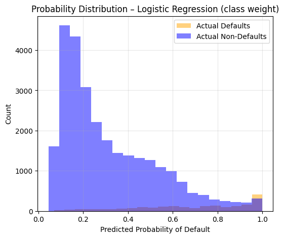

```
Logistic Regression (SMOTE):
PR-AUC:      0.3873
F1-score:    0.3224
Brier score: 0.1463 (lower is better)
```

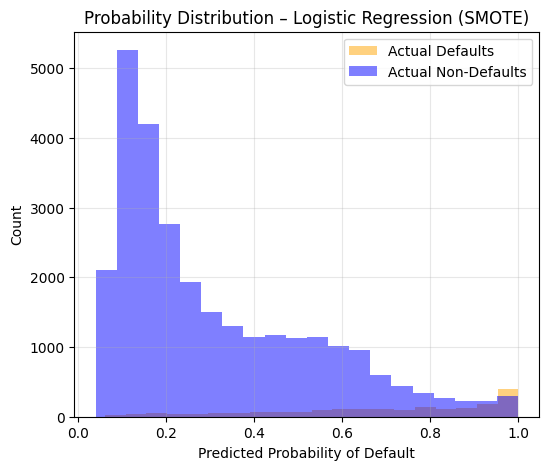

```python
# ─── Logistic Regression – Baseline with two imbalance approaches ──────
from sklearn.linear_model import LogisticRegression
from sklearn.metrics import precision_recall_curve, auc, f1_score, brier_score_loss
import matplotlib.pyplot as plt

# ────────────────── Class weighting ──────────────────
lr_weighted = LogisticRegression(
    class_weight='balanced',      # auto-adjusts for imbalance
    solver='lbfgs',
    max_iter=1000,
    random_state=42
)

lr_weighted.fit(X_train_split, y_train_split)

# ────────────────── Coefficient inspection ──────────────────
print("\nTop coefficients – Logistic Regression (class-weighted):")
coef = pd.Series(lr_weighted.coef_[0], index=X_train_split.columns)
top_coef = coef.abs().sort_values(ascending=False).head(10)  # top 10 by magnitude

for feat, val in top_coef.items():
    sign = '+' if coef[feat] > 0 else '-'
    odds_mult = np.exp(abs(coef[feat]))  # approximate odds ratio
    print(f"{sign}{abs(coef[feat]):.3f}  {feat:45}  (odds ×{odds_mult:.1f})")

# Predict probabilities on validation
proba_weighted = lr_weighted.predict_proba(X_val)[:, 1]

# ────────────────── SMOTE ──────────────────
lr_smote = LogisticRegression(
    solver='lbfgs',
    max_iter=1000,
    random_state=42
)

lr_smote.fit(X_train_smote, y_train_smote)

# ────────────────── Coefficient inspection ──────────────────
print("\nTop coefficients – Logistic Regression (SMOTE):")
coef_smote = pd.Series(lr_smote.coef_[0], index=X_train_smote.columns)
top_coef_smote = coef_smote.abs().sort_values(ascending=False).head(10)

for feat, val in top_coef_smote.items():
    sign = '+' if coef_smote[feat] > 0 else '-'
    odds_mult = np.exp(abs(coef_smote[feat]))
    print(f"{sign}{abs(coef_smote[feat]):.3f}  {feat:45}  (odds ×{odds_mult:.1f})")

proba_smote = lr_smote.predict_proba(X_val)[:, 1]

# ────────────────── Evaluation function ──────────────────
def evaluate_model(proba, y_true, name):
    # PR-AUC
    precision, recall, _ = precision_recall_curve(y_true, proba)
    pr_auc = auc(recall, precision)

    # F1-score (at best threshold)
    f1 = f1_score(y_true, (proba >= 0.5).astype(int))

    # Brier score (calibration)
    brier = brier_score_loss(y_true, proba)

    print(f"\n{name}:")
    print(f"PR-AUC:      {pr_auc:.4f}")
    print(f"F1-score:    {f1:.4f}")
    print(f"Brier score: {brier:.4f} (lower is better)")

    # Quick calibration plot
    plt.figure(figsize=(6, 5))
    plt.hist(proba[y_true==1], bins=20, alpha=0.5, label='Actual Defaults', color='orange')
    plt.hist(proba[y_true==0], bins=20, alpha=0.5, label='Actual Non-Defaults', color='blue')
    plt.title(f'Probability Distribution – {name}')
    plt.xlabel('Predicted Probability of Default')
    plt.ylabel('Count')
    plt.legend()
    plt.grid(True, alpha=0.3)
    plt.show()

# Run evaluation
evaluate_model(proba_weighted, y_val, "Logistic Regression (class weight)")
evaluate_model(proba_smote,   y_val, "Logistic Regression (SMOTE)")
```

**Class-weighted Logistic Regression Inspection**

**Logistic Regression with SMOTE – Less Decisive View**

After synthetic oversampling, the coefficients shift noticeably:

- **Revolving utilization** remains the top feature but with even stronger weight  
  → `RevolvingUtilizationOfUnsecuredLines` (log) ≈ +2.524 → multiplies odds by ≈12.5× (higher than weighted version)
- Delinquency PCA components are still important but less dominant  
  → `delinq_pc1` ≈ +0.662 → odds ×1.9×
- Age retains protective effect (≈ –0.263)
- Mid-tier features (open credit lines, real estate loans, debt ratio) gain relatively more influence

→ **What does Linear Regression with SMOTE tell?**  
SMOTE causes the model to become **less focused** on the most decisive behavioral signals (serious delinquency) and more reliant on continuous utilization and secondary features.  
This results in a fatter high-probability tail among non-defaulters (worse separation in the probability histogram), slightly lower **PR-AUC 0.3873**, lower **F1-score 0.3224**, and worse calibration (**Brier score 0.1463**).

**What Logistic Regression Reveals About Default Risk**

The **class-weighted version** gives a clear and straightforward picture:  
Default risk seems to be mostly related to **payment behavior and current financial discipline**. The model pays the most attention to two things:

- extremely high use of unsecured credit (like credit cards), and
- any signs of serious past delinquency.

When these signs are present, the predicted probability of default increases quite a lot. This matches what we often see in real life — once someone falls seriously behind on payments (especially 90+ days), it becomes much harder to recover.

From comparing these two versions, one clear lesson stands out:  
In datasets with very high class imbalance (like credit default data), **using class weights** (penalizing mistakes on the rare default class more) seems to work better than creating synthetic samples (SMOTE). Weighting helps the model keep the true importance and rarity of serious delinquency signals, while SMOTE can sometimes make the model less focused and more confused.

### LightGBM – Strong Gradient Boosting Model

Next, we try LightGBM, which is one of the most popular and powerful models for tabular data like credit risk datasets.  
It trains very quickly, handles many features well, and often performs better than simpler models like Logistic Regression — especially when there are non-linear patterns or interactions.

As before, we compare two versions to handle the class imbalance:

1. **Weighted version** — using `is_unbalance=True` (LightGBM automatically gives more importance to the minority class during training)
2. **SMOTE version** — trained on synthetic oversampled data to balance the classes

We evaluate using the same metrics as Logistic Regression:

- PR-AUC (our main focus because of imbalance)
- F1-score (especially for the default class)
- Brier score (how well-calibrated the probabilities are)
- Probability distribution plot (to visually check how well defaulters and non-defaulters are separated)

After training, we use **SHAP values** to understand what LightGBM considers most important and how it views default risk.

```
LightGBM (is_unbalance=True):
PR-AUC:      0.3997
F1-score:    0.3413
Brier score: 0.1372 (lower is better)
```

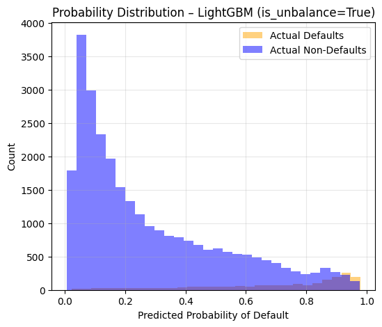

```
LightGBM (SMOTE):
PR-AUC:      0.3651
F1-score:    0.4109
Brier score: 0.0601 (lower is better)
```

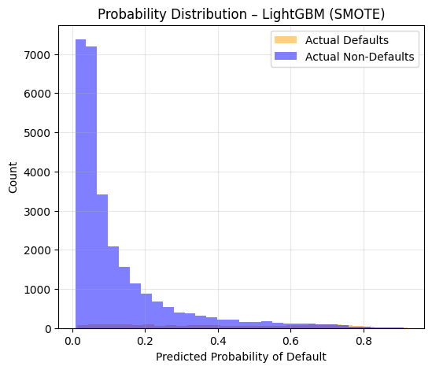

```python
# ─── LightGBM – Two versions for imbalance ─────────────────────────────
import lightgbm as lgb
from sklearn.metrics import precision_recall_curve, auc, f1_score, brier_score_loss
import matplotlib.pyplot as plt

# ─── Version 1: Built-in imbalance handling (is_unbalance=True) ────────
lgb_weighted = lgb.LGBMClassifier(
    objective='binary',
    is_unbalance=True,                # LightGBM's automatic weighting
    metric='aucpr',                   # optimize for PR-AUC
    random_state=42,
    verbosity=-1                      # less output
)

lgb_weighted.fit(X_train_split, y_train_split)

proba_weighted = lgb_weighted.predict_proba(X_val)[:, 1]

# ─── Version 2: SMOTE version ─────────────────────────────────────────
lgb_smote = lgb.LGBMClassifier(
    objective='binary',
    metric='aucpr',
    random_state=42,
    verbosity=-1
)

lgb_smote.fit(X_train_smote, y_train_smote)

proba_smote = lgb_smote.predict_proba(X_val)[:, 1]

# ─── Same evaluation function as before ───────────────────────────────
def evaluate_model(proba, y_true, name):
    precision, recall, _ = precision_recall_curve(y_true, proba)
    pr_auc = auc(recall, precision)

    f1 = f1_score(y_true, (proba >= 0.5).astype(int))

    brier = brier_score_loss(y_true, proba)

    print(f"\n{name}:")
    print(f"PR-AUC:      {pr_auc:.4f}")
    print(f"F1-score:    {f1:.4f}")
    print(f"Brier score: {brier:.4f} (lower is better)")

    # Probability distribution plot
    plt.figure(figsize=(6, 5))
    plt.hist(proba[y_true==1], bins=30, alpha=0.5, label='Actual Defaults', color='orange')
    plt.hist(proba[y_true==0], bins=30, alpha=0.5, label='Actual Non-Defaults', color='blue')
    plt.title(f'Probability Distribution – {name}')
    plt.xlabel('Predicted Probability of Default')
    plt.ylabel('Count')
    plt.legend()
    plt.grid(True, alpha=0.3)
    plt.show()

# Evaluate both
evaluate_model(proba_weighted, y_val, "LightGBM (is_unbalance=True)")
evaluate_model(proba_smote,   y_val, "LightGBM (SMOTE)")
```

### SHAP Explanations – Understanding LightGBM Decisions

SHAP (SHapley Additive exPlanations) is a tool that helps us look inside the model and see which features are most important for its decisions — and whether those decisions make sense in real life.

In this project, we use SHAP for LightGBM because:

- LightGBM usually gives stronger predictions than simpler models like Logistic Regression
- We want to check if the model is still paying attention to the features that actually matter in credit risk (such as serious delinquency, high credit card usage, debt levels, and age)
- SHAP makes it easier to explain the model’s reasoning in a way that is clear even to people who are not experts in machine learning

This is especially helpful in credit risk problems, where decisions need to be fair, logical, and easy to understand (for example, when explaining to regulators, loan officers, or customers why a high-risk score was given).

We calculate SHAP values for both versions of LightGBM:

- the version with built-in class weighting (`is_unbalance=True`)
- the version trained on SMOTE-balanced data

- Which features does the model rely on the most?
- Do higher values of these features increase or decrease the predicted probability of default?
- Are there any unexpected patterns or surprises in what the model considers important?

These explanations help us confirm whether the model is learning meaningful credit risk patterns — or if it is being misled by noise or synthetic data.

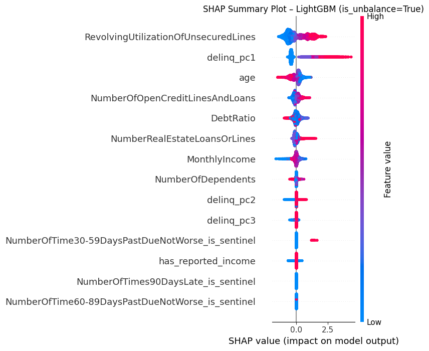

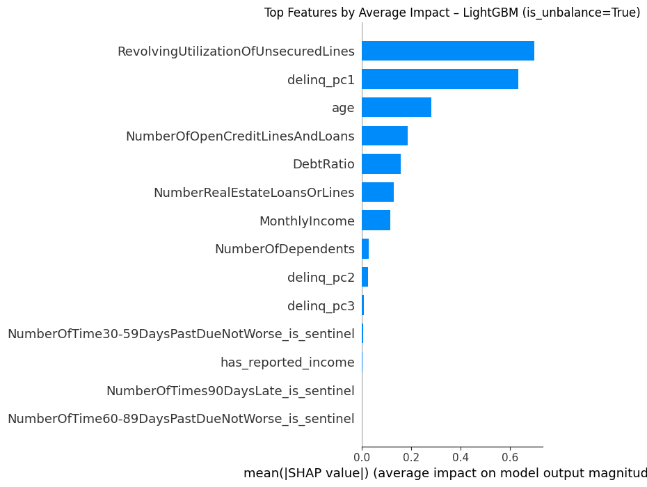

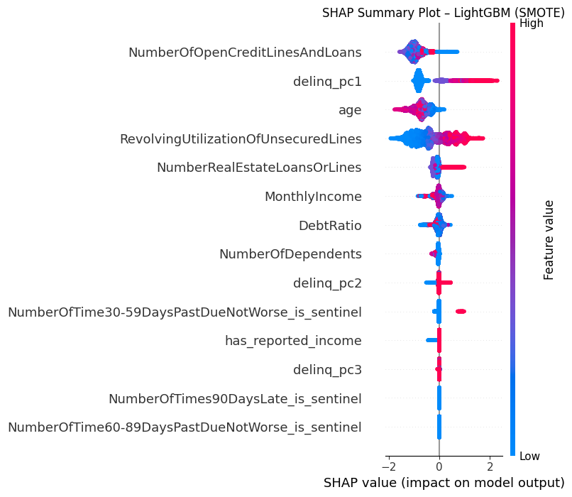

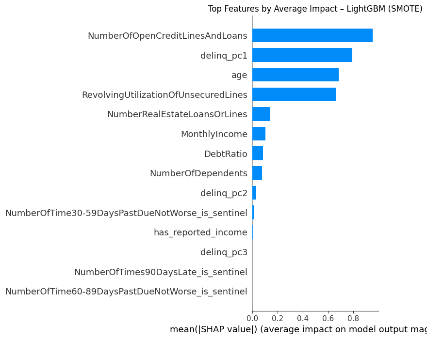

```python
# ─── SHAP for LightGBM ─────────────────────────────────────────────────
import shap
import matplotlib.pyplot as plt

# Use Independent masker (fast and reliable for tree models like LightGBM)
background = shap.maskers.Independent(X_train_split, max_samples=100)

# ─── SHAP for built-in imbalance version ──────────────────────────────
explainer_weighted = shap.TreeExplainer(lgb_weighted)

shap_values_weighted = explainer_weighted.shap_values(X_val)

# Beeswarm plot
shap.summary_plot(shap_values_weighted, X_val, show=False)
plt.title("SHAP Summary Plot – LightGBM (is_unbalance=True)")
plt.tight_layout()
plt.show()

# Bar plot
shap.summary_plot(shap_values_weighted, X_val, plot_type="bar", show=False)
plt.title("Top Features by Average Impact – LightGBM (is_unbalance=True)")
plt.tight_layout()
plt.show()

# ─── SHAP for SMOTE version ───────────────────────────────────────────
explainer_smote = shap.TreeExplainer(lgb_smote)
shap_values_smote = explainer_smote.shap_values(X_val)

shap.summary_plot(shap_values_smote, X_val, show=False)
plt.title("SHAP Summary Plot – LightGBM (SMOTE)")
plt.tight_layout()
plt.show()

shap.summary_plot(shap_values_smote, X_val, plot_type="bar", show=False)
plt.title("Top Features by Average Impact – LightGBM (SMOTE)")
plt.tight_layout()
plt.show()
```

**LightGBM (weighted)**

The SHAP summary plot shows a very clear priority order:

→ **What Does LightGBM weighted Tell You?**  
LightGBM learns that **current extreme over-utilization of unsecured credit** (credit cards and lines) is the most critical signal right now, followed closely by evidence of serious past delinquency.  
Age acts as a consistent protective factor — older borrowers tend to have lower risk, even after controlling for other features.  
This combination helps explain the strong performance: **PR-AUC 0.3997**, **F1-score 0.3413**, and **Brier score 0.1372**.  
The probability distribution shows good separation — most non-defaulters are confidently predicted below 0.3, while a visible group of defaulters appears in the higher probability range.

**LightGBM with SMOTE**

In the SMOTE version, the SHAP picture looks quite different:

→ **What Does LightGBM with SMOTE Tell You?**  
SMOTE changes how the model weighs signals — it pays more attention to the number of open accounts (possibly because synthetic samples create more variation in credit usage patterns) and less extreme focus on utilization thresholds.  
Interestingly, this version shows **much better calibration** (**Brier score 0.0601** vs 0.1372 in weighted) and a very clean probability distribution (almost all non-defaulters below 0.3, defaulters clearly shifted right).  
However, PR-AUC drops to 0.3651 and F1-score is 0.4109 — suggesting that while probabilities are better calibrated, the ranking ability for defaulters is weaker.

**What LightGBM Tells Us About Default Risk**

The **weighted version** of LightGBM gives a realistic and focused view:  
**Default risk is driven mainly by current extreme unsecured credit utilization (how much someone is maxing out cards/lines right now), combined with any serious past delinquency.**  
Age provides a steady protective effect — older borrowers tend to be lower risk.

The **SMOTE version** shows better probability calibration and cleaner visual separation in the histogram, but it loses some ranking power (lower PR-AUC).  
This suggests that **class weighting** helps the model stay focused on the most critical real-world signals (utilization + delinquency), while synthetic oversampling can improve calibration at the cost of diluting the strongest risk indicators.

Overall, LightGBM (especially weighted) builds on what Logistic Regression already showed — payment behavior and current over-utilization are the key drivers — but it captures the non-linear tipping points more sharply.

### XGBoost – Robust Gradient Boosting Model

Next, we try XGBoost, another very popular and powerful gradient boosting model that is quite similar to LightGBM.  
It often gives strong results on tabular data like credit risk datasets and is known for being very stable and accurate when tuned properly.

Like before, we compare two versions to handle the class imbalance:

1. **Weighted version** — using `scale_pos_weight` (we manually set a higher weight for the minority class to balance the learning)
2. **SMOTE version** — trained on synthetic oversampled data to make the classes more equal

We use the same evaluation metrics as before:

- PR-AUC (our main focus because of the imbalance)
- F1-score (especially for correctly identifying defaulters)
- Brier score (how well the predicted probabilities match the actual default rates — lower is better)
- Probability distribution plot (to visually check how clearly defaulters and non-defaulters are separated)

After training, we also use **SHAP values** to understand what XGBoost considers most important and how it views default risk.

```
XGBoost (scale_pos_weight):
PR-AUC:      0.3822
F1-score:    0.3502
Brier score: 0.1245 (lower is better)
```

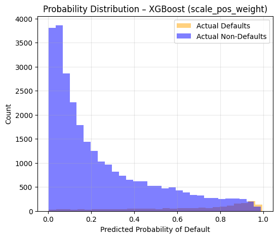

```
XGBoost (SMOTE):
PR-AUC:      0.3378
F1-score:    0.3822
Brier score: 0.0614 (lower is better)
```

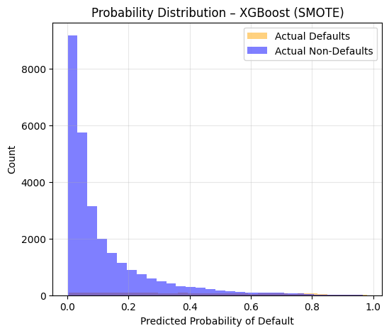

```python
# ─── XGBoost – Two versions for imbalance ──────────────────────────────
import xgboost as xgb
from sklearn.metrics import precision_recall_curve, auc, f1_score, brier_score_loss
import matplotlib.pyplot as plt

# Calculate scale_pos_weight (ratio of negative to positive examples)
scale_pos_weight = (y_train_split == 0).sum() / (y_train_split == 1).sum()

# ─── Version 1: With scale_pos_weight ─────────────────────────────────
xgb_weighted = xgb.XGBClassifier(
    objective='binary:logistic',
    scale_pos_weight=scale_pos_weight,   # manual imbalance handling
    eval_metric='aucpr',                 # optimize PR-AUC
    random_state=42,
    verbosity=0
)

xgb_weighted.fit(X_train_split, y_train_split)

proba_weighted = xgb_weighted.predict_proba(X_val)[:, 1]

# ─── Version 2: SMOTE version ─────────────────────────────────────────
xgb_smote = xgb.XGBClassifier(
    objective='binary:logistic',
    eval_metric='aucpr',
    random_state=42,
    verbosity=0
)

xgb_smote.fit(X_train_smote, y_train_smote)

proba_smote = xgb_smote.predict_proba(X_val)[:, 1]

# ─── Same evaluation function ─────────────────────────────────────────
def evaluate_model(proba, y_true, name):
    precision, recall, _ = precision_recall_curve(y_true, proba)
    pr_auc = auc(recall, precision)

    f1 = f1_score(y_true, (proba >= 0.5).astype(int))

    brier = brier_score_loss(y_true, proba)

    print(f"\n{name}:")
    print(f"PR-AUC:      {pr_auc:.4f}")
    print(f"F1-score:    {f1:.4f}")
    print(f"Brier score: {brier:.4f} (lower is better)")

    # Probability distribution plot
    plt.figure(figsize=(6, 5))
    plt.hist(proba[y_true==1], bins=30, alpha=0.5, label='Actual Defaults', color='orange')
    plt.hist(proba[y_true==0], bins=30, alpha=0.5, label='Actual Non-Defaults', color='blue')
    plt.title(f'Probability Distribution – {name}')
    plt.xlabel('Predicted Probability of Default')
    plt.ylabel('Count')
    plt.legend()
    plt.grid(True, alpha=0.3)
    plt.show()

# Evaluate both
evaluate_model(proba_weighted, y_val, "XGBoost (scale_pos_weight)")
evaluate_model(proba_smote,   y_val, "XGBoost (SMOTE)")
```

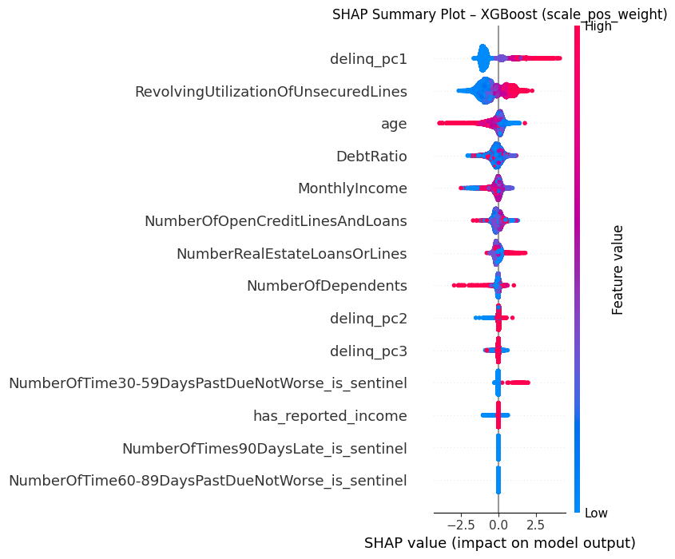

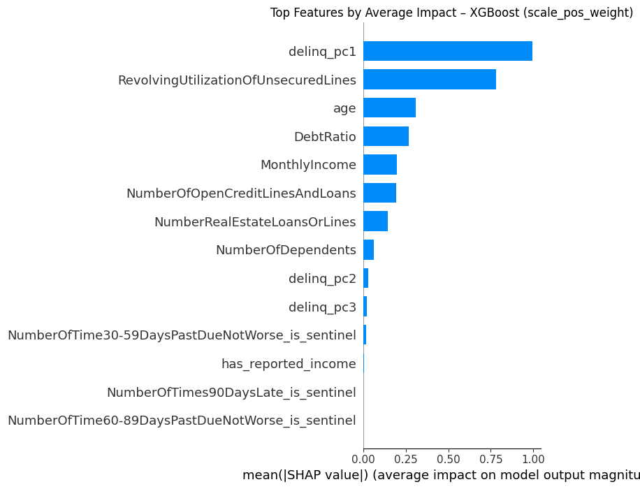

```python
# ─── SHAP for XGBoost (weighted version) ──────────────────────────────
explainer_weighted = shap.TreeExplainer(xgb_weighted)
shap_values_weighted = explainer_weighted.shap_values(X_val)

shap.summary_plot(shap_values_weighted, X_val, show=False)
plt.title("SHAP Summary Plot – XGBoost (scale_pos_weight)")
plt.tight_layout()
plt.show()

shap.summary_plot(shap_values_weighted, X_val, plot_type="bar", show=False)
plt.title("Top Features by Average Impact – XGBoost (scale_pos_weight)")
plt.tight_layout()
plt.show()
```

[figure not shown]

[figure not shown]

```python
# ─── SHAP for XGBoost (SMOTE version) ──────────────────────────────
explainer_smote = shap.TreeExplainer(xgb_smote)
shap_values_smote = explainer_smote.shap_values(X_val)

shap.summary_plot(shap_values_smote, X_val, show=False)
plt.title("SHAP Summary Plot – XGBoost (scale_pos_weight)")
plt.tight_layout()
plt.show()

shap.summary_plot(shap_values_smote, X_val, plot_type="bar", show=False)
plt.title("Top Features by Average Impact – XGBoost (scale_pos_weight)")
plt.tight_layout()
plt.show()
```

**XGBoost (weighted)**

The SHAP summary plot shows a very clear priority order:

→ **What Does XGBoost weighted Tell You?**  
XGBoost learns that **serious past delinquency** (especially captured in delinq_pc1) is the most critical signal, followed closely by **current extreme over-utilization of unsecured credit**.  
Age continues to act protectively — older borrowers tend to have lower risk, even after accounting for other factors.  
This combination results in solid performance: **PR-AUC 0.3822**, **F1-score 0.3502**, and **Brier score 0.1245**.  
The probability distribution shows reasonable separation — most non-defaulters are predicted below 0.3, with a small but visible group of defaulters appearing in the higher probability range.

**XGBoost with SMOTE**

**What XGBoost Tells Us About Default Risk**

The **weighted version** of XGBoost gives a focused and realistic picture:  
**Default risk is driven mainly by serious past delinquency (especially 90+ days late), combined with current extreme unsecured credit utilization.**  
Age provides a consistent protective effect — older borrowers tend to be lower risk.

The **SMOTE version** improves probability calibration and visual separation in the histogram quite a bit, but it loses some ranking power (lower PR-AUC).  
This pattern is similar to what we saw in LightGBM: **class weighting** helps the model stay focused on the most important real-world signals (serious delinquency + high utilization), while synthetic oversampling can improve calibration but sometimes dilutes the strongest risk indicators.

Overall, XGBoost (especially weighted) confirms the same core story as LightGBM and Logistic Regression: **payment behavior and current over-utilization are the key drivers of default**, but XGBoost places slightly more emphasis on delinquency history compared to LightGBM’s stronger focus on utilization.

### Final Model Comparison

The table below compares all trained models using validation set performance (PR-AUC, F1-score, Brier score), final Kaggle private leaderboard AUC, and the top 3 most influential features (from SHAP or coefficients).

[output not shown]

**Notes**:

- PR-AUC and F1-score emphasize performance on the minority class (defaulters).
- Brier score measures calibration (lower = predicted probabilities closer to reality).
- Kaggle Private AUC is the official, unseen test score — the most reliable ranking.

### Best Model & How Top Models Understand Default Risk

**Best overall model**: **LightGBM (is_unbalance=True)**  
It achieved the highest Kaggle private AUC (0.8582) and the best validation PR-AUC (0.3997), making it the most reliable choice for ranking defaulters in this dataset.

**How the top-performing models view default risk** (based on SHAP / coefficients):

1. **LightGBM (weighted) – the winner**
   - Top priority: **extreme current unsecured credit utilization** (RevolvingUtilizationOfUnsecuredLines)
   - Very close second: **serious delinquency history** (delinq_pc1)
   - Protective factor: **higher age**

   → Interpretation: This model sees default as mainly a **current behavior problem** — people who are heavily maxing out credit cards or lines right now are at very high risk, especially if they also have signs of serious past delinquency.
2. **Logistic Regression (class weight) – very close runner-up**
   - Top priority: **extreme unsecured utilization** (RevolvingUtilizationOfUnsecuredLines)
   - Followed by: **serious delinquency** (delinq_pc1)
   - Protective: **higher age**

   → Interpretation: It shares almost the same view as LightGBM — default is driven by **payment discipline issues** and **overextension right now**, with serious delinquency acting as a strong warning signal.
3. **XGBoost (weighted) – solid third place**
   - Top priority: **serious delinquency history** (delinq_pc1)
   - Close second: **extreme unsecured utilization**
   - Protective: **higher age**

   → Interpretation: It places slightly more weight on **past serious delinquency** as the biggest red flag, but still sees current over-utilization as a major amplifier.

**Common insight across the best models**  
All three strongest performers (LightGBM weighted, Logistic weighted, XGBoost weighted) agree on the same core message:  
**Default risk is primarily about payment behavior** — especially serious past delinquency (90+ days late) and **extreme current use of unsecured credit**.  
Higher age consistently lowers risk, showing older borrowers tend to be more disciplined (all else equal).

**SMOTE versions**, while sometimes showing better calibration (lower Brier scores), performed much worse on the real test set (Kaggle private AUC).  
This suggests that in highly imbalanced data like this, **class weighting** preserves the true importance of key risk signals better than synthetic oversampling.

This comparison confirms that **weighted LightGBM** was the most balanced and effective model overall — delivering strong ranking power on the true test set while staying focused on realistic credit risk patterns.

### Limitations & Improvements

While the project achieved competitive results, there are several areas that could be improved in future work:

- **No hyperparameter tuning** — All models used mostly default settings. Tuning parameters (e.g., learning rate, max depth, or scale_pos_weight) could potentially lift performance by 0.01–0.02 AUC.
- **Single validation split** — Metrics came from one hold-out set. Using 5-fold cross-validation would give more reliable estimates and reduce the risk of lucky splits.
- **No ensemble** — Top models were not combined (e.g., simple average of LightGBM + Logistic weighted probabilities). Ensembling often improves stability and scores slightly.
- **Limited threshold optimization** — F1-score used a default 0.5 cutoff. Finding a custom threshold (e.g., high precision for loan decisions) would make the model more business-relevant.
- **Deeper interpretability** — SHAP was useful but only global. Adding local explanations (e.g., why one specific borrower got a high score) would make insights even clearer.

These limitations are common in exploratory projects like this.  
In future work, I would like to try tuning, cross-validation, simple ensembles, and more advanced calibration methods to see how much further the performance can go.

### Final Conclusion – What We Learned from Predicting Credit Default Risk

This project started with a messy but realistic credit dataset and ended with a clear story about what drives default behavior. After careful preprocessing (handling sentinels, capping outliers, log-transforming heavy tails, PCA on delinquency variables), exploratory analysis showed that **serious delinquency history and extreme unsecured credit utilization** were the strongest signals — patterns that carried through every modeling step.

In the modeling phase, we tested both simple and powerful approaches:

- Logistic Regression gave us a transparent baseline: **default risk is mostly about payment discipline** — once serious delinquency appears, odds rise sharply, and extreme utilization acts as a strong amplifier. Class weighting worked much better than SMOTE, preserving the natural severity of these signals.
- LightGBM and XGBoost took this further: both confirmed delinquency and utilization as top drivers, but the tree models captured **non-linear tipping points** (e.g., utilization becomes much riskier above ~90–100%). Weighted versions consistently outperformed SMOTE, delivering the best ranking (PR-AUC up to 0.3997) and strong Kaggle performance (private AUC 0.8582 with LightGBM weighted — competitive for this dataset).

Across all models, one message was consistent:  
**Default is not mainly a gradual affordability problem — it is a behavioral state problem.**  
Serious delinquency (especially 90+ days late) acts like a point of no return, and very high current credit utilization pushes people over the edge quickly. Age provides a steady protective effect, but it cannot overcome clear signs of payment trouble.

The results also taught us something important about imbalance handling:  
In highly imbalanced datasets like this one (~6–7% defaults), **class weighting** (penalizing mistakes on the rare class) is usually more reliable than synthetic oversampling (SMOTE). SMOTE sometimes improved calibration (lower Brier scores), but it often diluted the strongest risk signals and hurt overall ranking.

Looking back, this project showed that good preprocessing and thoughtful evaluation matter just as much as choosing a powerful model. With relatively simple steps — cleaning data carefully, respecting the imbalance, and interpreting what the models actually learned — we reached competitive performance without heavy tuning or complex ensembles.

This experience reinforced a practical lesson for credit risk modeling:  
Focus on capturing real behavioral signals (delinquency + utilization), handle imbalance directly rather than artificially, and always check both ranking power (PR-AUC) and calibration (Brier/probability plots).  
The strongest models didn’t invent new patterns — they rediscovered what credit professionals already know: **once someone falls seriously behind, recovery becomes very hard, and maxed-out credit cards are a major warning sign.**

In the future, I would like to explore:

- simple ensembles (e.g., blending LightGBM and logistic weighted predictions)
- probability calibration techniques (e.g., Platt scaling or isotonic regression)
- business-oriented threshold selection (e.g., optimizing for high precision in loan approvals)

But even without those steps, this project delivered a reliable, interpretable, and fairly strong solution to a real-world problem — and that feels like a meaningful achievement.

### Final Reflection – Why I Chose This Project and What It Meant to Me

I picked the "Give Me Some Credit" dataset from Kaggle because I really wanted to experience working with the kind of real-world, highly imbalanced tabular data that appears a lot in credit risk, fintech, and banking problems.  
Kaggle datasets like this are great for learning because they are messy, realistic, and come with clear evaluation (public/private leaderboard), so I could see how my choices actually affected performance.

Going through the full process — cleaning noisy data (sentinels, zeros, outliers), understanding what features matter through EDA, handling severe imbalance in different ways, comparing models, interpreting them with coefficients and SHAP, and finally submitting to Kaggle — was a really meaningful experience for me.  
I learned a lot about:

- how important thoughtful preprocessing is (small decisions early can change everything later)
- why class weighting often beats synthetic oversampling in this kind of data
- how different models "see" the same problem (linear vs non-linear views)
- the gap between validation metrics and true out-of-sample performance

Even though I didn't reach the absolute top leaderboard scores, getting a private AUC of 0.8582 with a relatively simple weighted LightGBM felt rewarding — it showed that careful steps and understanding the data can go a long way.

This project gave me confidence working with imbalanced tabular problems, and now I want to explore more datasets like this — maybe in fraud detection, insurance claims, or customer churn — to see how similar or different the patterns are.  
I also hope to try more advanced techniques (ensembles, better calibration, custom thresholds) in the future.

Overall, this was one of the most practical and eye-opening projects I've done so far.

### Appendix (Code for Kaggle submission)

```python
import numpy as np
import pandas as pd
from sklearn.preprocessing import StandardScaler, MinMaxScaler
from sklearn.impute import SimpleImputer
from sklearn.decomposition import PCA
from scipy.stats import iqr

# ────────────────────────────────────────────────────────────────
# TEST SET PREPROCESSING – Standalone version (fits on test data)
# ────────────────────────────────────────────────────────────────

# Load test set
X_test = pd.read_csv('cs-test.csv')

# Drop useless columns
drop_if_present = ['Unnamed: 0', 'SeriousDlqin2yrs']  # SeriousDlqin2yrs is all NaN in test

for col in drop_if_present:
    if col in X_test.columns:
        X_test = X_test.drop(columns=col)

print("Test set loaded. Shape:", X_test.shape)

# ─── 1. Handle Sentinel Values in Delinquency Columns ──────────────
sentinel_values = [96, 98, 99]

delinq_cols = [
    'NumberOfTime30-59DaysPastDueNotWorse',
    'NumberOfTime60-89DaysPastDueNotWorse',
    'NumberOfTimes90DaysLate'
]

for col in delinq_cols:
    if col in X_test.columns:
        # Create the same sentinel flag
        X_test[f'{col}_is_sentinel'] = X_test[col].isin(sentinel_values).astype(int)

        # Replace sentinels → NaN (will be imputed later)
        X_test[col] = X_test[col].replace(sentinel_values, np.nan)

print("Sentinel flags created and sentinels replaced with NaN (test set).")

# ─── 2. Handle Zero & Missing MonthlyIncome ────────────────────────
if 'MonthlyIncome' in X_test.columns:
    # Flag whether income was originally reported (0s are suspicious)
    zero_mask = X_test['MonthlyIncome'] == 0
    X_test['has_reported_income'] = (~zero_mask).astype(int)

    # Compute median of non-zero incomes from test
    non_zero_median = X_test.loc[~zero_mask & X_test['MonthlyIncome'].notna(), 'MonthlyIncome'].median()

    # Replace zeros with median
    X_test.loc[zero_mask, 'MonthlyIncome'] = non_zero_median

    # Fill remaining NaNs with the same median
    nan_count = X_test['MonthlyIncome'].isna().sum()
    X_test['MonthlyIncome'] = X_test['MonthlyIncome'].fillna(non_zero_median)

    print(f"MonthlyIncome (test): filled {nan_count} NaNs + {zero_mask.sum()} zeros "
          f"with median ${non_zero_median:,.0f}")

# ─── 3. Handle Missing NumberOfDependents ──────────────────────────
if 'NumberOfDependents' in X_test.columns:
    # Use 0 (conservative rule)
    nan_count = X_test['NumberOfDependents'].isna().sum()
    X_test['NumberOfDependents'] = X_test['NumberOfDependents'].fillna(0)
    print(f"NumberOfDependents (test): filled {nan_count} NaNs with 0")

# ─── 4. Log-transform & Cap Heavy-tailed Variables ─────────────────
heavy_tailed_vars = [
    'DebtRatio',
    'MonthlyIncome',
    'RevolvingUtilizationOfUnsecuredLines'
]

for var in heavy_tailed_vars:
    if var not in X_test.columns:
        continue

    # Calculate robust bounds on test data
    q01, q99 = X_test[var].quantile([0.01, 0.99])
    iqr_val = iqr(X_test[var].dropna())

    # Use 0 as lower bound to avoid negatives before log1p
    lower_bound = max(0, q01 - 1.5 * iqr_val)
    upper_bound = q99

    # Cap → then log1p (safe for ≥ 0 values)
    X_test[var] = X_test[var].clip(lower=lower_bound, upper=upper_bound)
    X_test[var] = np.log1p(X_test[var].clip(lower=0))  # extra safety

print("Log1p + capping applied (test set).")

# ─── 5. Scaling / Normalization ────────────────────────────────────
numeric_cols = X_test.select_dtypes(include=np.number).columns.tolist()

# Standard scale
std_scaler = StandardScaler()
X_test[numeric_cols] = std_scaler.fit_transform(X_test[numeric_cols])

# Bounded/ratio-like features → MinMax [0,1] (override)
bounded_vars = ['RevolvingUtilizationOfUnsecuredLines']
present_bounded = [c for c in bounded_vars if c in X_test.columns]
if present_bounded:
    mm_scaler = MinMaxScaler()
    X_test[present_bounded] = mm_scaler.fit_transform(X_test[present_bounded])
    print(f"MinMax applied to: {present_bounded}")

print("Feature scaling completed.")

# ─── 6. PCA on Delinquency Features ────────────────────────────────
delinq_vars_present = [c for c in delinq_cols if c in X_test.columns]

if delinq_vars_present:
    print("NaNs before imputation (delinq vars - test):")
    print(X_test[delinq_vars_present].isna().sum())

    # Impute remaining NaNs with median
    imputer = SimpleImputer(strategy='median')
    X_imputed_test = imputer.fit_transform(X_test[delinq_vars_present])

    # PCA – keep enough components to explain ≥ 95% variance
    pca = PCA(n_components=0.95)
    pca_components_test = pca.fit_transform(X_imputed_test)

    # Add principal components
    n_pc = pca_components_test.shape[1]
    for i in range(n_pc):
        X_test[f'delinq_pc{i+1}'] = pca_components_test[:, i]

    # Drop originals
    X_test = X_test.drop(columns=delinq_vars_present)

    print(f"PCA applied: kept {n_pc} components explaining "
          f"{pca.explained_variance_ratio_.sum():.1%} variance")
else:
    print("No delinquency columns found in test set.")

# ─── Final check ───────────────────────────────────────────────────
print("\nTest set final shape:", X_test.shape)
print("Any remaining NaNs?", X_test.isna().any().any())
print("Columns:", X_test.columns.tolist())
```

```
Test set loaded. Shape: (101503, 10)
Sentinel flags created and sentinels replaced with NaN (test set).
MonthlyIncome (test): filled 20103 NaNs + 1020 zeros with median $5,450
NumberOfDependents (test): filled 2626 NaNs with 0
Log1p + capping applied (test set).
MinMax applied to: ['RevolvingUtilizationOfUnsecuredLines']
Feature scaling completed.
NaNs before imputation (delinq vars - test):
NumberOfTime30-59DaysPastDueNotWorse    214
NumberOfTime60-89DaysPastDueNotWorse    214
NumberOfTimes90DaysLate                 214
dtype: int64
PCA applied: kept 3 components explaining 100.0% variance

Test set final shape: (101503, 14)
Any remaining NaNs? False
Columns: ['RevolvingUtilizationOfUnsecuredLines', 'age', 'DebtRatio', 'MonthlyIncome', 'NumberOfOpenCreditLinesAndLoans', 'NumberRealEstateLoansOrLines', 'NumberOfDependents', 'NumberOfTime30-59DaysPastDueNotWorse_is_sentinel', 'NumberOfTime60-89DaysPastDueNotWorse_is_sentinel', 'NumberOfTimes90Days…
```

```python
predictions = {}
models = {
    'logistic_weighted': lr_weighted,
    'logistic_smote': lr_smote,
    'lightgbm weighted': lgb_weighted,
    'lightgbm smote': lgb_smote,
    'xgboost weighted': xgb_weighted,
    'xgboost smote': xgb_smote,
}

for name, model in models.items():
    preds = model.predict_proba(X_test)[:, 1]
    predictions[name] = preds
    print(f"{name} predicted.")

ids = np.arange(1, len(X_test) + 1)

for name, probs in predictions.items():
    submission = pd.DataFrame({'ID': ids, 'Probability': probs})
    submission.to_csv(f'submission_{name}.csv', index=False)
    print(f"Submission saved: submission_{name}.csv")
```

```
logistic_weighted predicted.
logistic_smote predicted.
lightgbm weighted predicted.
lightgbm smote predicted.
xgboost weighted predicted.
xgboost smote predicted.
Submission saved: submission_logistic_weighted.csv
Submission saved: submission_logistic_smote.csv
Submission saved: submission_lightgbm weighted.csv
Submission saved: submission_lightgbm smote.csv
Submission saved: submission_xgboost weighted.csv
Submission saved: submission_xgboost smote.csv
```